[Go to Home page](https://jaydeepsb.github.io/deepdive/)

# Analysing my running/cycling activities to assess my progress over a year!

These are my own running activities. These activities were recording using Polar Vantage M, GPS watch.

```python
import json
import glob
import datetime
from numpy import array, mean, std, arange, append, vstack
import numpy as np
from itertools import compress
from pylab import plot_date, figure, fill_between, xticks, ylabel, hist, title, subplots, rcParams
import os
import pandas as pd
import pylab as plt
import seaborn as sns
```

```python
%matplotlib inline
#notebook
rcParams['figure.figsize'] = [10,8]
sns.set()
sns.set(font_scale=1.5)
```

## For this task a class is written. One can call the methods within and directly get the output visualizations describing the activity.

You can use this script for your own analysis of similar data files from Polar watch. Each activity is a json file format. If you have your own Polar watch based activities you can download them in a folder and run the below script through them.

## Set path of folder containing all the json files

Folder containing all the running data files by Polar watch (json files).

```python
fpath = r'path\to\folder\containing\json\data\files'
```

```python
class activitiesPolar(object):
    def __init__(self,wdir=fpath, whichactivity="RUNNING", readall=False, lowerPaceThr=9.5):
        #
        #==== List all json files in the given folder ==========
        self.fpath = fpath + r'\\'
        self.allfiles = [ os.path.basename(x) for x in glob.glob(fpath+'\*.json')]

        #==== Select only the training session files ===========
        self.allfiles = [v for v in self.allfiles if (v.split('-')[0] == 'training') & (v.split('-')[1] == 'session')]
        self.readActivityFiles()

    def readActivityFiles(self):
        activity_summary = array(['start_time', 'activity_type', 'activity_distance', 'activity_duration', 'avg_speed', 'max_speed', 'avg_hrate', 'avg_cadence'])

        for filename in self.allfiles:
            with open(self.fpath + filename, 'r') as infile:
                self.data = json.load(infile)
                start_time = datetime.datetime.fromisoformat(self.data['startTime'])
                activity_type = self.data['exercises'][0]['sport']
                activity_distance = self.data['distance']/1e3 #km
                activity_duration = float(self.data['duration'].split("PT")[1].split("S")[0])/3600 #in hours
                avg_speed = self.data['exercises'][0]['speed']['avg']
                max_speed = self.data['exercises'][0]['speed']['max']
                #=============
                if 'cadence' in self.data['exercises'][0].keys():
                    avg_cadence = self.data['exercises'][0]['cadence']['avg']
                else: avg_cadence = float('NaN')

                #=============
                if 'heartRate' in self.data['exercises'][0].keys():
                    avg_hrate = self.data['exercises'][0]['heartRate']['avg']
                else: avg_hrate = float('NaN')
                #=============
                activity_array = array([start_time, activity_type, activity_distance, activity_duration, avg_speed, max_speed, avg_hrate, avg_cadence ])
                #print(len(activity_array))

            activity_summary = vstack((activity_summary, activity_array))
            # save a Pandas DF.
        self.activity_summary_df = pd.DataFrame(activity_summary[1:,:], columns=activity_summary[0,:])
        running_mask = self.activity_summary_df['activity_type'] == 'RUNNING'
        cycling_mask = self.activity_summary_df['activity_type'] == 'CYCLING'
        #===
        self.running_df = self.activity_summary_df[running_mask]
        self.cycling_df = self.activity_summary_df[cycling_mask]

    def describeActivities(self):
        #==========================
        plt.figure()
        df_temp = runs.activity_summary_df['activity_type'].value_counts()
        df_temp = df_temp.sort_values(ascending=True)
        plt.title("Number of activities", fontsize=16)
        b = plt.pie(df_temp, labels=df_temp.index.values, autopct=lambda p: '{:.2f}%({:.0f})'.format(p,(p/100)*df_temp.sum()))
        #b = plt.pie(df_temp, labels=df_temp.index.values, autopct=lambda p: '{:.2f}%({:.0f})'.format(p,(p/100)*df_temp.sum()))
        #self.activity_summary_df.activity_type.value_counts().plot(kind='pie', title='Activities by number'+
        #                                                    '(total ' + str(self.activity_summary_df.shape[0]) + ')')
        #============================
        plt.figure()
        df_temp = self.activity_summary_df.groupby(pd.Grouper(key='activity_type')).sum()['activity_duration']
        df_temp = df_temp.sort_values(ascending=True)
        plt.title("Duration (Hours)", fontsize=16)
        b = plt.pie(df_temp, labels=df_temp.index.values, autopct=lambda p: '{:.2f}%({:.1f})'.format(p,(p/100)*df_temp.sum()))
        #self.activity_summary_df.groupby(pd.Grouper(key='activity_type')).sum()['activity_duration'].plot(kind='pie',
        #                                                  title='Activities by duration')

    def describeStats(self, activity='running'):
        fig, ax = subplots(2,2, figsize=(6,6))
        plot_list = ['activity_distance', 'activity_duration', 'avg_speed', 'avg_hrate']
        for i,v in enumerate(plot_list):
            if activity == 'running':
                self.running_df[plot_list[i]].hist(bins=12, ax=ax.flatten()[i])
            elif activity == 'cycling':
                self.cycling_df[plot_list[i]].hist(bins=12, ax=ax.flatten()[i])
            ax.flatten()[i].set_title(plot_list[i])

    def getRunTimeline(self, activity='running', deltat='W'):
        """
        deltat = 'D', 'W', or 'M', 'Y' (i.e. day, week, month, year)
        """
        #====== running timeline =======
        self.df_run_timeline = pd.DataFrame()
        self.df_run_timeline['Time'] = pd.to_datetime(runs.running_df['start_time']).dt.round('D')#.apply(lambda x: x.date())
        self.df_run_timeline['activity_distance'] = runs.running_df['activity_distance']
        self.df_run_timeline['activity_duration'] = runs.running_df['activity_duration']
        self.df_run_timeline = self.df_run_timeline.groupby(pd.Grouper(key='Time', freq=deltat)).sum()
        #===============================
        #====== cycling timeline =======
        self.df_cycling_timeline = pd.DataFrame()
        self.df_cycling_timeline['Time'] = pd.to_datetime(runs.cycling_df['start_time']).dt.round('D')#.apply(lambda x: x.date())
        self.df_cycling_timeline['activity_distance'] = runs.cycling_df['activity_distance']
        self.df_cycling_timeline['activity_duration'] = runs.cycling_df['activity_duration']
        self.df_cycling_timeline = self.df_cycling_timeline.groupby(pd.Grouper(key='Time', freq=deltat)).sum()
        #===============================
        if activity == 'running':
            ax = self.df_run_timeline.plot(kind='bar', subplots=True)
        elif activity == 'cycling':
            ax = self.df_cycling_timeline.plot(kind='bar', subplots=True)
            pass
        #==== to Show only every kth time stamp, depending on what deltat is chosen
        if deltat == 'D':
            k = 10
        elif deltat == 'W':
            k = 5
        elif deltat == 'M' or 'Y':
            k = 1
            pass
        #================================
        xticklabels = []
        for i, t in enumerate(ax[1].get_xticklabels()):
            value = t.get_text()[:10]
            t.set_text(value)
            t.set_visible(False)
            if (i % k) == 0:
                t.set_visible(True)
            xticklabels.append(t)
        ax[1].set_xticklabels(xticklabels)


    def HRandSpeedProgress(self, activity='running', deltat='W'):
        if activity == 'running':
            (60.0/runs.running_df['avg_speed']).plot(kind=scatter)
```

## Using the class to analyse all my running data files

```python
runs = activitiesPolar(fpath,readall=True)
runs.activity_summary_df.head()
```

|  | start_time | activity_type | activity_distance | activity_duration | avg_speed | max_speed | avg_hrate | avg_cadence |
| --- | --- | --- | --- | --- | --- | --- | --- | --- |
| 0 | 2018-09-21 14:14:02 | CYCLING | 5.7106 | 0.284236 | 20.091 | 29.2 | NaN | NaN |
| 1 | 2018-09-21 19:20:13 | RUNNING | 4.0429 | 0.506354 | 7.98433 | 11.3 | NaN | 82 |
| 2 | 2018-09-22 17:27:47 | RUNNING | 6.3472 | 0.755069 | 8.40611 | 10.1 | NaN | 85 |
| 3 | 2018-09-24 09:04:05 | CYCLING | 5.4343 | 0.288056 | 18.8655 | 29.7 | NaN | NaN |
| 4 | 2018-09-24 16:47:30 | CYCLING | 5.7417 | 0.246979 | 23.2477 | 32.1 | NaN | NaN |

```
          Short  Long
CYCLING      27    20
RUNNING     105    30
SWIMMING      1     0
```

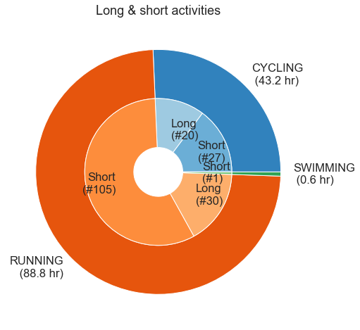

```python
#Compare long and short activities

thr_hrs = 0.75 #i.e. 45mins

df_temp = pd.DataFrame()
for act in runs.activity_summary_df['activity_type'].unique():
    #print(act)
    df_temp_short = runs.activity_summary_df[(runs.activity_summary_df['activity_type'] == act) &
                             (runs.activity_summary_df['activity_duration'] < thr_hrs)]['activity_type'].value_counts() #.sum()
    df_temp_short.name = 'Short'
    df_temp_long = runs.activity_summary_df[(runs.activity_summary_df['activity_type'] == act) &
                             (runs.activity_summary_df['activity_duration'] > thr_hrs)]['activity_type'].value_counts() #.sum()
    df_temp_long.name = 'Long'
    df_temp = pd.concat([df_temp,  pd.concat([df_temp_short, df_temp_long], axis=1) ])
df_temp.fillna(value=0,inplace=True)
df_temp = df_temp.astype('int')

fig, ax = plt.subplots()
size = 0.4

vals = df_temp.values
cmap = plt.get_cmap("tab20c")
outer_colors = cmap(np.arange(3)*4)
inner_colors = cmap(np.array([1, 2, 5, 6, 9, 10]))
#==== for labels print total hours
df_hours = runs.activity_summary_df.groupby(pd.Grouper(key='activity_type')).sum()['activity_duration'].round(1)
#========

outer_wedges, outer_texts = ax.pie(vals.sum(axis=1), radius=1, colors=outer_colors,
       wedgeprops=dict(width=size, edgecolor='w'), labels = [v + "\n (" + str(df_hours[v]) + " hr)" for v in df_temp.index.values])

innerlabels = [v+ '\n'+ '(#'+ str(df_temp.values.flatten()[i])+')' for i,v in enumerate(list(df_temp.columns)*3)]

inner_wedges, inner_texts = ax.pie(vals.flatten(), radius=1-size, colors=inner_colors,
       wedgeprops=dict(width=size, edgecolor='w') , labels = innerlabels, labeldistance=0.6) #, labels = innerlabels, labeldistance=0.6

inner_texts[-1].set_text('')

ax.set(aspect="equal", title='Long & short activities')
#ax.legend( list(df_temp.index.values) + list(df_temp.columns)*3)
plt.show()
```

# Overview of all types of activities

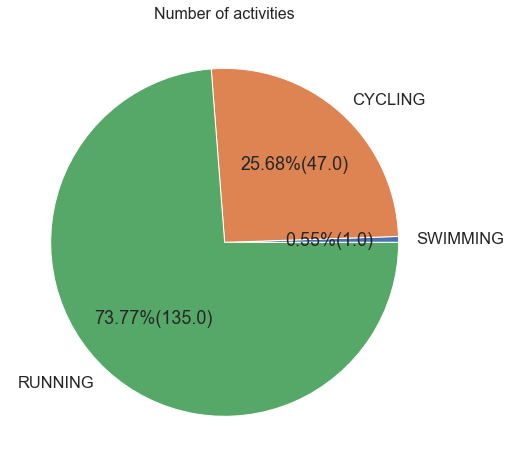

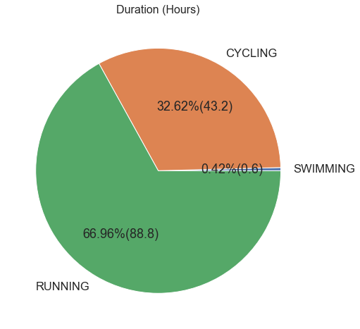

```python
runs.describeActivities()
```

```python
runs.running_df.head()
```

|  | start_time | activity_type | activity_distance | activity_duration | avg_speed | max_speed | avg_hrate | avg_cadence |
| --- | --- | --- | --- | --- | --- | --- | --- | --- |
| 1 | 2018-09-21 19:20:13 | RUNNING | 4.0429 | 0.506354 | 7.98433 | 11.3 | NaN | 82 |
| 2 | 2018-09-22 17:27:47 | RUNNING | 6.3472 | 0.755069 | 8.40611 | 10.1 | NaN | 85 |
| 6 | 2018-09-25 16:46:36 | RUNNING | 7.575 | 0.884896 | 8.56032 | 10.1 | NaN | 83 |
| 7 | 2018-09-26 19:28:35 | RUNNING | 4.8703 | 0.644653 | 7.55492 | 10.4 | NaN | 82 |
| 10 | 2018-10-04 08:43:01 | RUNNING | 3.4985 | 0.487292 | 7.17948 | 10.2 | NaN | 79 |

```python
runs.cycling_df.head()
```

|  | start_time | activity_type | activity_distance | activity_duration | avg_speed | max_speed | avg_hrate | avg_cadence |
| --- | --- | --- | --- | --- | --- | --- | --- | --- |
| 0 | 2018-09-21 14:14:02 | CYCLING | 5.7106 | 0.284236 | 20.091 | 29.2 | NaN | NaN |
| 3 | 2018-09-24 09:04:05 | CYCLING | 5.4343 | 0.288056 | 18.8655 | 29.7 | NaN | NaN |
| 4 | 2018-09-24 16:47:30 | CYCLING | 5.7417 | 0.246979 | 23.2477 | 32.1 | NaN | NaN |
| 5 | 2018-09-25 09:33:20 | CYCLING | 5.7211 | 0.314097 | 18.2144 | 25 | NaN | NaN |
| 8 | 2018-09-28 16:57:30 | CYCLING | 5.7181 | 0.293854 | 20.2187 | 28.4 | NaN | NaN |

## statistics of all runs

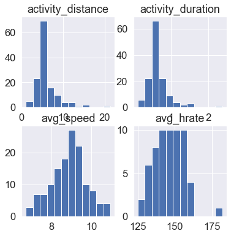

```python
runs.describeStats(activity='running')
```

## statistics of all cycling sessions

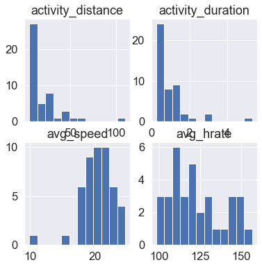

```python
runs.describeStats(activity='cycling')
```

## Timeline of activities

### Running timeline.

Accumulate activities over duration deltat= 'D', 'W', 'M' or 'Y' for (days, weeks, months, year)

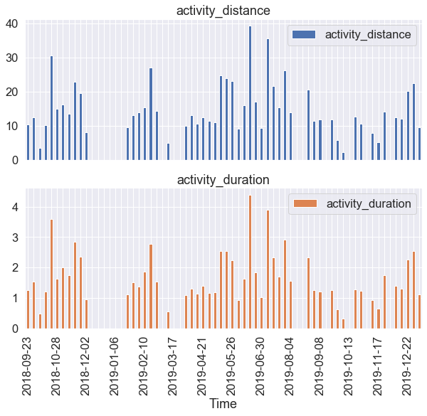

```python
runs.getRunTimeline( activity='running', deltat='W')
```

### Cycling timeline.

Accumulate activities over duration deltat= 'D', 'W', 'M' or 'Y' for (days, weeks, months, year)

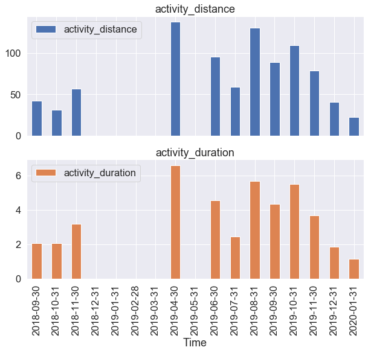

```python
runs.getRunTimeline( activity='cycling', deltat='M')
```

## Heart rate and pace progression over time

Although overall trend of the pace is going downwards , i.e. improvement, however, the avg. heart rate values are quite scattered.

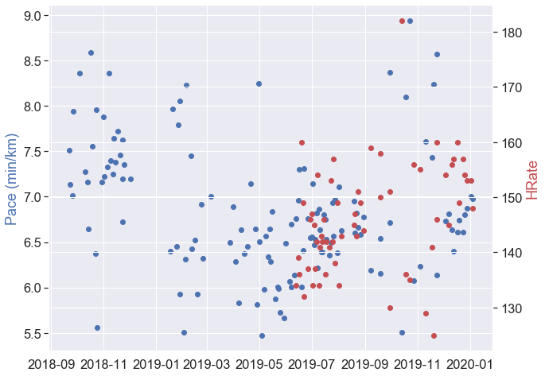

```python
from pylab import plot, twinx
figure()
plot(runs.running_df['start_time'], 60./runs.running_df['avg_speed'], 'bo')
ylabel("Pace (min/km)", color='b')
twinx()
plot(runs.running_df['start_time'], runs.running_df['avg_hrate'], 'ro')
ylabel("HRate", color='r')
```

### Improvements (or not)

Improvement is when, over time value of pace decreases, and the corresponding avg. heart rate also lowers. Below, I create a feature, product of pace and hrate, normalized to 7min/km and heart rate of 140 (arbitrarily chosen normalization). (Pace/7.0 x Hrate/140.0) should decrease over time. Instead we see an increase, indicating no improvement! Perhaps, I should run more consistantly!

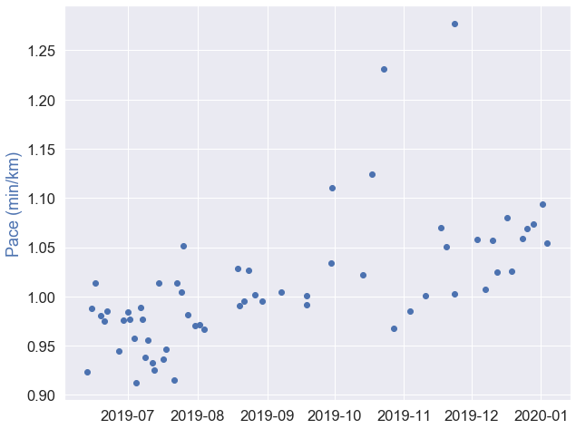

```python
figure()
plot(runs.running_df['start_time'], 60./runs.running_df['avg_speed']*runs.running_df['avg_hrate']/140./7., 'bo')
ylabel("Pace (min/km)", color='b')
#twinx()
#plot(runs.running_df['start_time'], runs.running_df['avg_hrate'], 'ro')
#ylabel("HRate", color='r')
```